# Homework 4&5 solutions

Shalini Mishra

11/16/2019

##Q1 $H_{0}: d_{1}$ is correct $H_{1}: d_{2}$ is correct Condidering one possible decision procedure to fail to reject H_0 if X=4 or X=6  
*a* the probability of a Type I error $H_{0}$ is true,Reject $H_{0}$

```r
#Probability of when null hypothesis is true and we don't reject null hypothesis
#Prob(X=4|X=6) for d1=P(X=4)+P(X=6)
prob_correct <- 0.2 +0.3
alpha <- 1-prob_correct
cat("alpha:probability of type 1 error",alpha)
```

```
## alpha:probability of type 1 error 0.5
```

*b* the probability of a Type II error

```r
#Probability of when null hypothesis is true and we reject null hypothesis
#Prob(X=4|X=6) for d2=P(X=4)+P(X=6)
beta <- 0.2 +0.1
cat("beta:probability of type 2 error",beta)
```

```
## beta:probability of type 2 error 0.3
```

## Q2

ATQ, Hypotheses for our analysis are: - $H_{0}$ : $\mu \geq 32$ - $H_{a}$ : $< 32 $

*Please look into attached doc for Type 1, Type 2 error analysis*

```r
library(PASWR2)
q2_data <- read.csv('Question2.csv')
#sample size
n <- 110
x_bar <- mean(q2_data$Minutes)
z_score <- (x_bar - 32)/8/sqrt(110)

prob <- pnorm(0.05,z_score,lower.tail=FALSE)
prob
```

```
## [1] 0.4701823
```

```r
#Type 1 error would be a more dangerous in this scenario than type 2
#Hence, we will go for a significance of 5%

#Our sample size >30 and population standard deviation is known.
#Calculate the critical value for rejection region
X_c <- qnorm(0.05,32,8/sqrt(110),lower.tail=TRUE)
X_c
```

```
## [1] 30.74535
```

```r
#A financial analyst has determined that a 2-minute reduction in the average break would increase productivity
#So considering our mu as 30(=32-2)
beta <- pnorm(X_c,30,8/sqrt(110),lower.tail=FALSE)
cat('beta:',beta) #~16.4%
```

```
## beta: 0.1642429
```

probability of erroneously concluding that the renovation would not be successful= Probability of conducting a type 2 error = $\beta$ The value of $\beta$ can be reduced by: 1. increasing the sample size, n 2. increasing the value of $\alpha$

## Q3

It is an example of one-way ANOVA We have price as a factor Levels: Different prices provided i.e. 9$, 10$ and 11$ Since, it’s a one way ANOVA, our treatments are same as levels (20 stores under each) - $H_{0}$ : $*9 =* {10} =_{11} $ - $H_{a}$ : Atleast one of $\mu_9$,$\mu_{10}$,$\mu_{11}$ is different

The manager is unsure if the sale would differ significantly among these 3 prices (levels) stated above

```r
#sample means
x_9 <- 153.60
x_10 <- 151.50
x_11 <- 133.25

#sample sizes
n_9 <- 20
n_10 <- 20
n_11 <- 20

#standard deviations
s9 <- 25.57
s10 <- 30.39
s11 <- 25.03

#grand_mean
x_bar <- (x_9*n_9 +x_10*n_10 +x_11*n_11)/(n_9+n_10+n_11)
x_bar
```

```
## [1] 146.1167
```

```r
#compute SST -Sample Square for Treatments (between treatment variation)
sst <- n_9*(x_9-x_bar)^2 + n_10*(x_10-x_bar)^2 + n_11*(x_11-x_bar)^2
sst
```

```
## [1] 5010.633
```

```r
#compute SSE -Sample Square for Errors (within treatment variation)
sse <- (n_9-1)*(s9^2)+(n_10-1)*(s10^2)+(n_11-1)*(s11^2)
sse
```

```
## [1] 41873.68
```

```r
#number of treatments,k(9$,10$,11$)
k <- 3

#compute MSE and MST
mst <- sst/(k-1)
cat("mst=",mst)
```

```
## mst= 2505.317
```

```r
mse <- sse/(60-k)
cat("mse=",mst)
```

```
## mse= 2505.317
```

```r
#compute F statistic
f <- mst/mse
f
```

```
## [1] 3.41033
```

```r
#We reject null hypothesis if our f-statistic,f > f-statistic(0.05,k-1=2,n-k=60-3=57)
qf(0.05, df1=2, df2=60-k, lower.tail=FALSE)
```

```
## [1] 3.158843
```

```r
pf(f,2,57,lower.tail=FALSE)
```

```
## [1] 0.03990587
```

As the observed F statistic is greater than 3.16,f-statistic(0.05,2,57) & p-value<0.05 -> Reject H0 At 5% significance level, there is sufficient evidence to support the claim that the sales vary significantly across these three different prices Manager was unsure if the sale would vary significantly. But the results from ANOVA test tells otherwise.

## Q4

*a.* It is a case of one-way ANOVA We have cereals as a factor Levels: Different cereals provided i.e. 1,2,3 & 4 Since, it’s a one way ANOVA, our treatments are same as levels For mean age, - $H_{0}$ : $*{1} =* {2}= *3 =*{4} $ - $H_{a}$ : Atleast one of $\mu_{1}$,$\mu_{2}$,$\mu_3$,$\mu_{4}$ is different

```r
q4 <- read.csv('Question4.csv')
#Changing data type for cereal type to factors
q4$Cereal <- factor(q4$Cereal)
#Run one-way ANOVA
ANOVA_4 <- aov(q4$Age ~ q4$Cereal)
summary(ANOVA_4)
```

```
##              Df Sum Sq Mean Sq F value   Pr(>F)
## q4$Cereal     3   3366  1122.0    25.6 9.96e-15 ***
## Residuals   291  12752    43.8
## ---
## Signif. codes:  0 '***' 0.001 '**' 0.01 '*' 0.05 '.' 0.1 ' ' 1
```

```r
#Check for normality
#Creating a residual plot
model <- lm(q4$Age ~ q4$Cereal)
resids <- residuals(model)

nortest::ad.test(resids)
```

```
##
##  Anderson-Darling normality test
##
## data:  resids
## A = 0.74779, p-value = 0.051
```

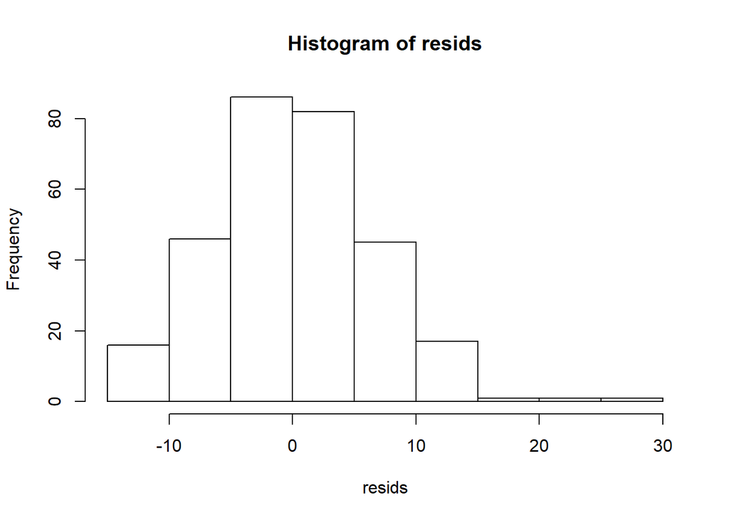

```r
hist(resids)
```

```r
#p-value>0.05 Failed to reject
#Histogram also resembles (right-skewed) distribution


#Check for variance
car::leveneTest(q4$Age ~ q4$Cereal)
```

```
## Levene's Test for Homogeneity of Variance (center = median)
##        Df F value   Pr(>F)
## group   3  12.087 1.77e-07 ***
##       291
## ---
## Signif. codes:  0 '***' 0.001 '**' 0.01 '*' 0.05 '.' 0.1 ' ' 1
```

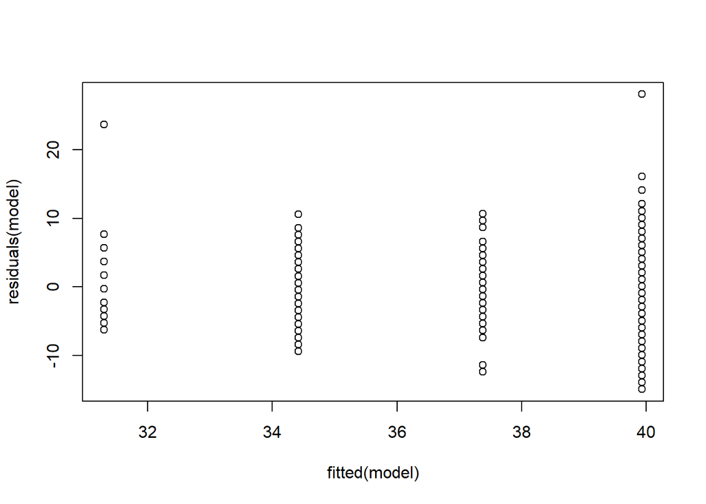

```r
#Plot for variance test
plot(fitted(model), residuals(model))
```

```r
#p-value<0.05 --rejecting the null hypothesis of constant variance
#The plot for variance also shows that the variance is increasing not constant

#As normality test passed but variance test failed, we will go for Welch test
oneway.test(q4$Age ~ q4$Cereal, var.equal = FALSE)
```

```
##
##  One-way analysis of means (not assuming equal variances)
##
## data:  q4$Age and q4$Cereal
## F = 25.154, num df = 3.00, denom df = 132.24, p-value = 6.11e-13
```

As p-value<<0.05, We reject null hypothesis stating that there is no difference in age of the consumers of the four cereals. At 5% significance level, there is sufficient evidence to support the claim that the age vary significantly across the consumers of the 4 different cereals

*b*  
It is a case of one-way ANOVA We have cereals as a factor Levels: Different cereals provided i.e. 1,2,3 & 4 Since, it’s a one way ANOVA, our treatments are same as levels For mean income, - $H_{0}$ : $*{1} =* {2}= *3 =*{4} $ - $H_{a}$ : Atleast one of $\mu_{1}$,$\mu_{2}$,$\mu_3$,$\mu_{4}$ is different

```r
#Check for normality
#Creating a residual plot
model <- lm(q4$Income ~ q4$Cereal)
resids <- residuals(model)

nortest::ad.test(resids)
```

```
##
##  Anderson-Darling normality test
##
## data:  resids
## A = 0.38897, p-value = 0.3826
```

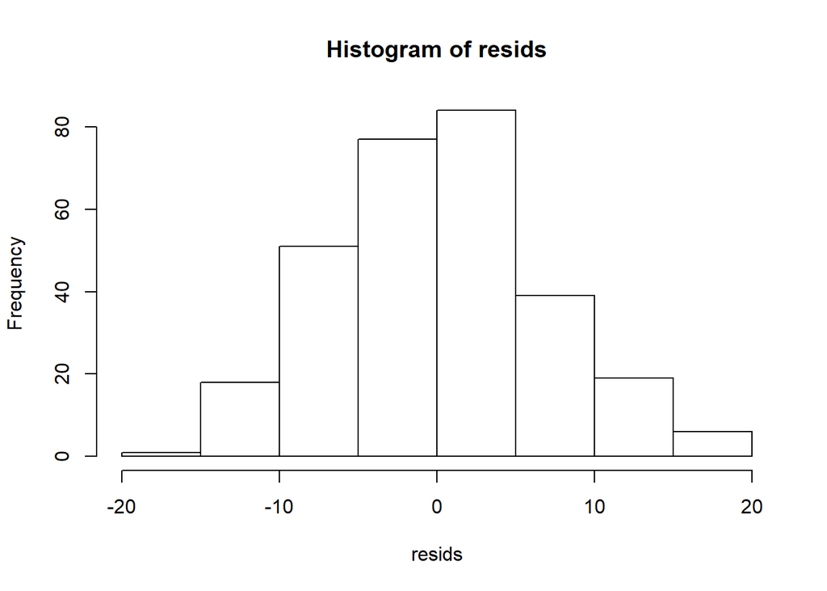

```r
hist(resids)
```

```r
#p-value>>0.05-satisfies normality
#Histogram also resembles normal distribution like plot

#Check for variance
car::leveneTest(q4$Income ~ q4$Cereal)
```

```
## Levene's Test for Homogeneity of Variance (center = median)
##        Df F value Pr(>F)
## group   3   1.302  0.274
##       291
```

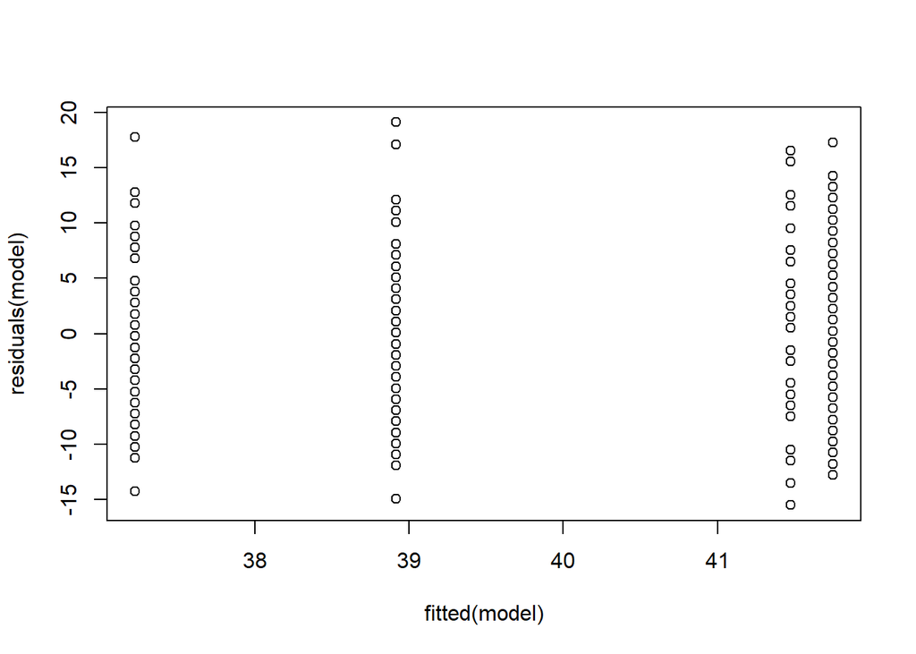

```r
#Plot for variance test
plot(fitted(model), residuals(model))
```

```r
#p-value>0.05 --failing to reject null hypothesis:constant variance
#The plot for variance also shows that the variance is constant

#As both normality test & variance test were passed
#Run one-way ANOVA
ANOVA_4 <- aov(q4$Income ~ q4$Cereal)
summary(ANOVA_4)
```

```
##              Df Sum Sq Mean Sq F value  Pr(>F)
## q4$Cereal     3   1007   335.8   7.372 8.9e-05 ***
## Residuals   291  13256    45.6
## ---
## Signif. codes:  0 '***' 0.001 '**' 0.01 '*' 0.05 '.' 0.1 ' ' 1
```

```r
#As we reject null hypothesis, we proceed with tukey
TukeyHSD(ANOVA_4)
```

```
##   Tukey multiple comparisons of means
##     95% family-wise confidence level
##
## Fit: aov(formula = q4$Income ~ q4$Cereal)
##
## $`q4$Cereal`
##          diff        lwr      upr     p adj
## 2-1 1.6913580 -1.2382761 4.620992 0.4437664
## 3-1 4.2527778  0.7269324 7.778623 0.0107801
## 4-1 4.5255255  1.7745433 7.276508 0.0001679
## 3-2 2.5614198 -0.8088534 5.931693 0.2042006
## 4-2 2.8341675  0.2856270 5.382708 0.0225024
## 4-3 0.2727477 -2.9434438 3.488939 0.9962792
```

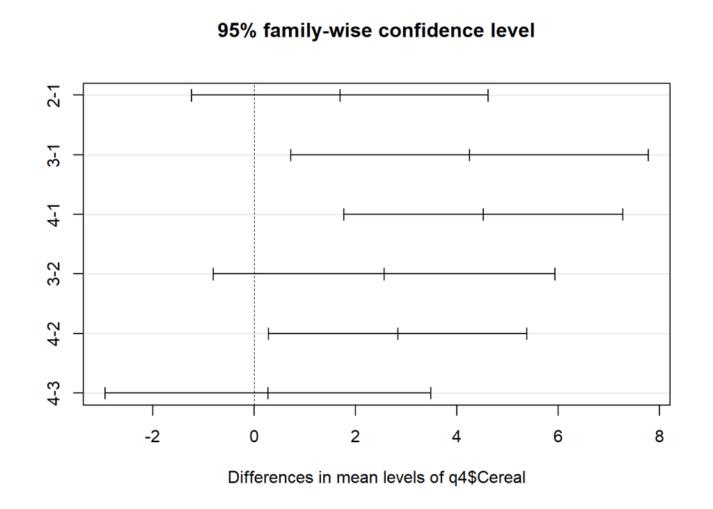

```r
plot(TukeyHSD(ANOVA_4))
```

As p-value<<0.05, We reject null hypothesis stating that there is no difference in Income of the consumers of the four cereals. At 5% significance level, there is sufficient evidence to support the claim that the income vary significantly across the consumers of the 4 different cereals